# Ebola outbreak in southwest Uganda: state of the epidemic

Elisha Are, Jeremy Bingham

10 January 2020

## Introduction

This report summarises available data from the ongoing Ebola outbreak taking place in Southwest Uganda, ongoing since 2019-10-24. The most recent case report included in the available data was made on 2020-02-02. The mean reporting delay in the data is 6 days. A total of 59 cases (15 male, 44 female), (2 suspected, 16 probable, 41 confirmed) have been reported to date. The estimated case fatality rate is 69.8%.

## Incidence

Figure 2 below shows the weekly number of reported Ebola cases from the beginning of the epidemic up until the onset week of the last reported case. Week 9 of the outbreak witnessed the highest number of Ebola cases so far, with 11 cases occurring.

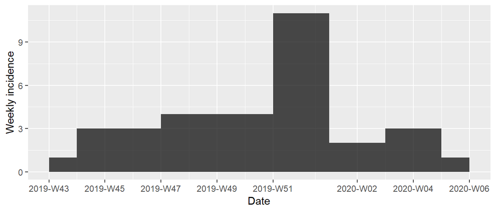

Figure 3 below shows the cumulative number of Ebola cases from the date of the first reported case to the date the last case was reported.

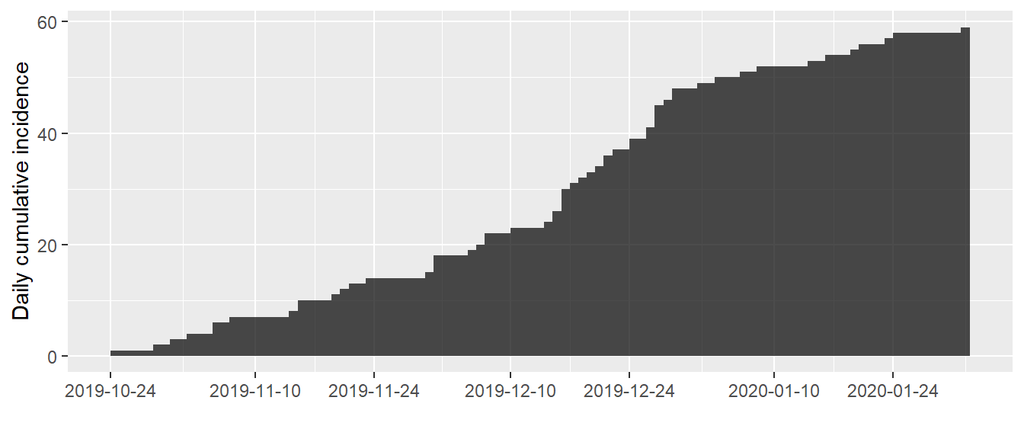

The daily cumulative incidence plot provides a visualisation of the progression of the outbreak, including the rapidity of the outbreak’s growth at a daily level.

## Case fatality rate

- The estimated case fatality rate is 69.8%. The case fatality rate among females is 72.5% while the case fatality rate among males is 58.3%.

##### Details regarding case fatality estimation:

The case fatality rate is estimated under the assumption that cases for which the date of death is not reported have recovered. As such, recently-reported cases should not be included in this calculation, since they are relatively likely to still be alive regardless of their prospects for recovery, and their inclusion would result in under-estimation of the case fatality.

Using more conservative requirement for inclusion, namely that delay between case onset and most recent report in the data set is greater than the maximum delay between onset and death (24 days), the case fatality is calculated to be 69.2%.

The crude case fatality ($\frac{\text{n}_\text{deaths}}{\text{n}_\text{cases}}$) is 71.2%.

To be interpreted with some caution (due to smaller sample sizes): the case fatality rate per `status’ is found to be (using the same method as described above): Case fatality in ‘Confirmed’ cases: 60. Case fatality in ‘Probable’ cases: 100. Case fatality in ‘Suspected’ cases: NaN.

## Reporting delays

In most of the reported cases, there are delays between the date of onset and the date of report of the cases. The length of the delay may be a good indicator of the effectiveness of the health system of the community. It could also be a useful metric when estimating the number of cases that might still be unreported. Figure 4 shows the distribution of the delay between date of onset and date of report.

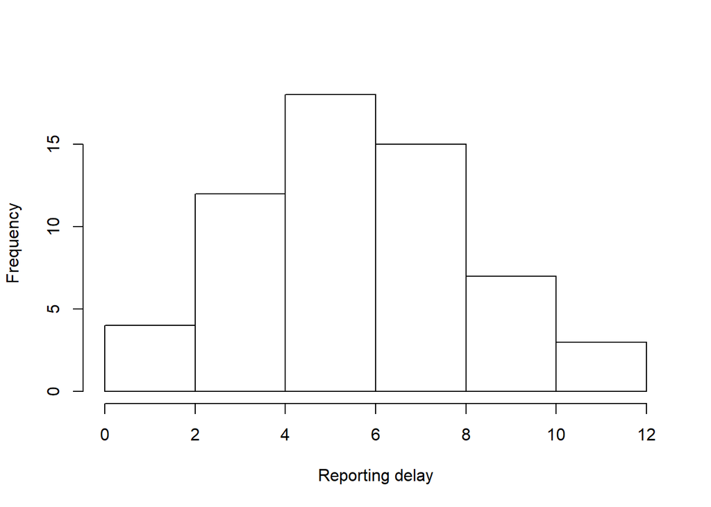

## Life history parameters

##### Incubation period

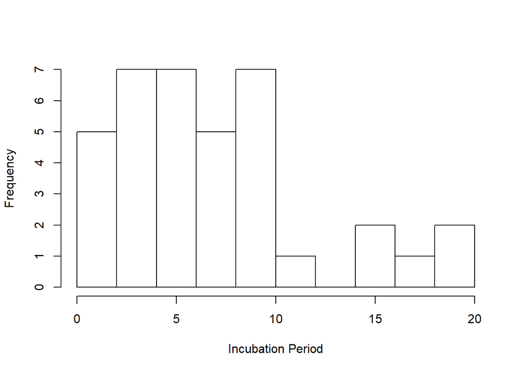

The mean incubation period is 7.4 days, with a standard deviation of 5 days.

##### Delays between onset and death in fatal cases

Figure 5 presents the time delay from the onset of disease to the time of death in fatal cases.

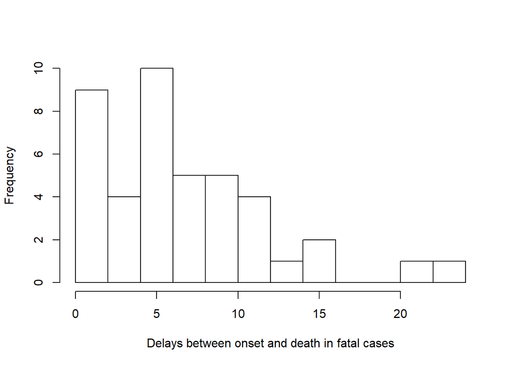

Understanding the life history of this strain of Ebola, in this context, may be valuable for comparison with other outbreaks, forecast modelling, and patient management.

##### Serial intervals

The mean serial interval in an outbreak is the mean delay between symptoms in a “source” or “infector” case and symptoms in subsequently infected cases. The suspected source of infection if known for 63% of cases reported to date. Among these cases, the mean serial interval is 10.3513514 days. A histogram of the observed serial intervals is plotted below.

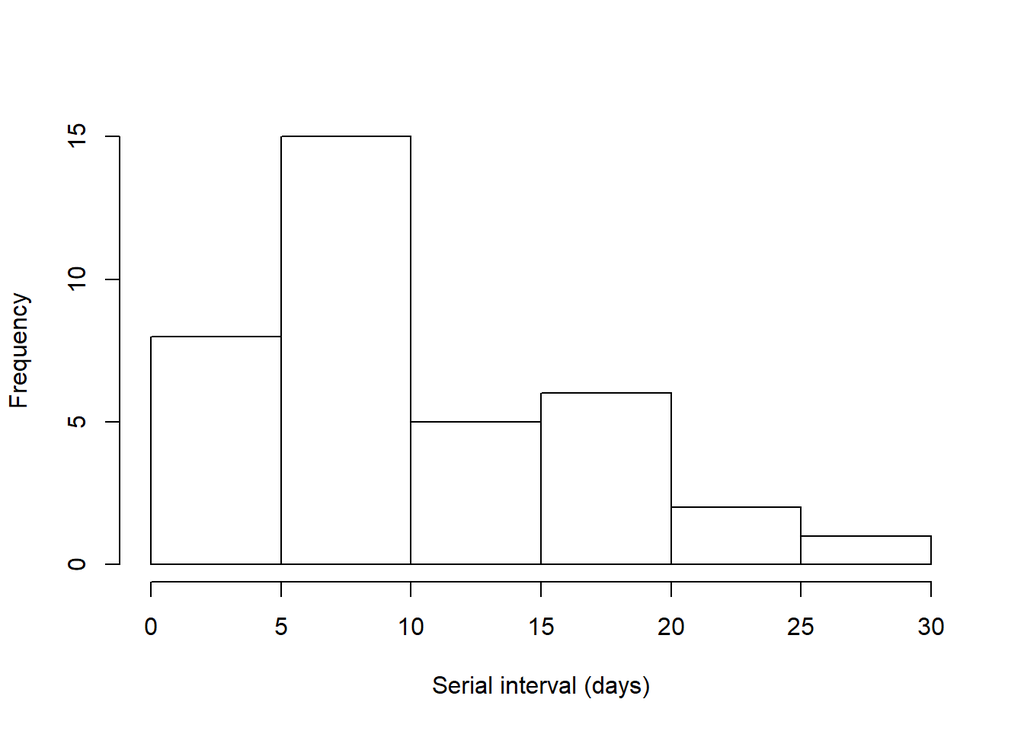

##### Generation time

The mean generation time of infections in an outbreak is the mean delay between exposure in an “infector” (or source case) and exposure in cases infected by the “infector”. The suspected source of infection, and the date of exposure for the source of infection, is known for 25% of cases reported to date. The mean generation time (for cases where the generation time is known) is 8.3 days, with a standard deviation of 6.3 days.

##### R0 estimation

```
## Best fitting GT distribution is a weibull distribution with mean = 10.3521 and sd = 6.197104 .
```

The estimated value of R0 in outbreak at hand is 1.3003474, with a $95\%$ confidence interval of (1.0182142;1.6505022).

## Fitting an exponential growth model to the weekly incidence

An exponential growth model is fit to the weekly incidence data using the “fit” function from the R package “incidence”. Weekly (rather than daily) incidence is used due to the sparsity of days with non-zero incidence during the early phase of the outbreak. These plots should be interpreted with caution due to the limited sample size of the available data.

A single exponential model (solid black lines) with confidence intervals (dashed lines) is plotted alongside the weekly incidence (red dots).

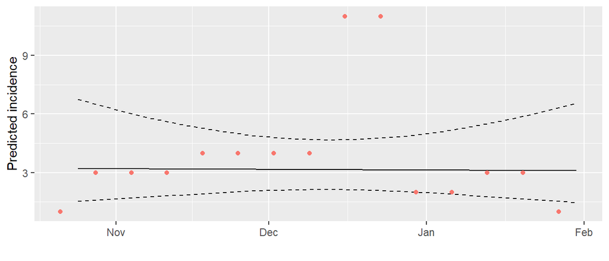

The exponential daily growth rate in the single-model fit is estimated to be -0.00034 $\approx 0$ with a 95% confidence interval of (-0.013; 0.013). A positive growth rate value would indicate that an outbreak is growing, while a negative value would suggest a declining outbreak. However recent shifts in the dynamics of an outbreak may take some time before being reflected in the growth rate estimate. In addition, observed reporting delays (mean delay of $\approx$ 6, max/min delays of 1 and 12) make it difficult to draw definite conclusions, but would make it less likely (than the estimated growth rate would imply) that the epidemic is slowing down. The approximately flat exponential fit suggests that the dynamics of the outbreak may be fairly static, and ongoing surveillance and action are required.

### References

Kamvar, Zhian N, Jun Cai, Juliet RC Pulliam, Jakob Schumacher, and Thibaut Jombart. 2019. “Epidemic Curves Made Easy Using the R Package Incidence.” *F1000Research* 8. Faculty of 1000 Ltd.

Obadia, Thomas, Romana Haneef, and Pierre-Yves Boëlle. 2012. “The R0 Package: A Toolbox to Estimate Reproduction Numbers for Epidemic Outbreaks.” *BMC Medical Informatics and Decision Making* 12 (1). BioMed Central: 147.

Wallinga, Jacco, and Marc Lipsitch. 2007. “How Generation Intervals Shape the Relationship Between Growth Rates and Reproductive Numbers.” *Proceedings of the Royal Society B: Biological Sciences* 274 (1609). The Royal Society London: 599–604.